# Dada2 Workflow

Eric Malekos

April 25, 2020

## Introduction

#### Information Packed Tutorials:

https://benjjneb.github.io/dada2/tutorial.html - The official Dada2 Tutorial  
https://astrobiomike.github.io/amplicon/dada2_workflow_ex - A second helpful walkthrough  
**Most of the code that follows is a reproduction of code that was originally written up in these two sources**

You can find the raw R code used in this document here:  
https://github.com/ericmalekos/Microbe-Workflow  
Download the Microbiome-Dada2.R file

**Note**, some of the methods take a while and you may not want to run the whole script at once, or you may want to restart from a certain point in the pipeline. To accomplish this you can use the the R methods saveRDS and readRDS. This allows you to save any environmental variable and reload it in the future without worrying about formats.  
**Format:**

```r
saveRDS([variableToSave], [path/filename])

[variableName] = readRDS([path/filename])
```

**Example:**

```r
errF <- learnErrors(R1_filtFs, multithread=TRUE)
saveRDS(errF, "/intermediateData/errF.rds")

reloaded_errF <- readRDS("/intermediateData/errF.rds")
```

## Setting Up Environment

Install and load the dada2 package:

```r
if (!requireNamespace("BiocManager", quietly = TRUE))
    install.packages("BiocManager")
BiocManager::install("dada2", version = "3.10")
```

Set up your path variables and check that you find the expected files.

```r
library(dada2)
path = "/home/eric/projects/Microbiome"
dataFolder = "/Project_JA14487"

if(getwd() != path)
  setwd(path)

dataPath = paste0(path,dataFolder)
head(list.files(dataPath))
```

```
## [1] "D1S1_S86_L001_I1_001.fastq"  "D1S1_S86_L001_I2_001.fastq"
## [3] "D1S1_S86_L001_R1_001.fastq"  "D1S1_S86_L001_R2_001.fastq"
## [5] "D1S10_S87_L001_I1_001.fastq" "D1S10_S87_L001_I2_001.fastq"
```

### The Data

Below are the first two sequence entries from one of the fastq files. Each entry is composed of four lines:

1. Sequence metadata
2. The sequence
3. “+” sign
4. The Quality scores

```r
con <- file(paste0(dataPath,"/",list.files(dataPath)[3]),"r")
print(readLines(con,n=8))
```

```
## [1] "@M02288:44:000000000-AA5TT:1:1101:16134:2226 1:N:0:86"
## [2] "GTGTCAGCAGCCGCGGTAACACGTAGGCACCAAGCGTTATCCGGATTTATTGGGCGTAAA…"
## [3] "+"
## [4] "AAAABFFFFFFBGGGGEGGGGGFFGHCHCHFGHHGGEEEHHHGGGDGHHGHHGEHGEFGHFHFHHHGGGGFFGGEEFFFHHDEGHGGGF<EDDGHGHHHEGGFFHHGHHHGFFHFFCHCGEGDHFHHHGHHGHGHFHHFHHFFHHECGCEDGGGGCACCFGGGGGGGGGG;FEFFFDFDDEFFFFFDDAF@FFFFFFEFFDAEFB..9.FFEEFFAFBEFFFFCFCEBF.AEFFFF?F/B/9AAD??EFD"
## [5] "@M02288:44:000000000-AA5TT:1:1101:19861:2365 1:N:0:86"
## [6] "GTGCCAGCCGCCGCGGTAATACGGAGGGGGTTAGCGTTGTTCGGAATTACTGGGCGTAAA…"
## [7] "+"
## [8] "CCCCDFFCCCDBGGGGGGGGGGHGGGGGGGGGGHHGGGGGHHGGGGGHHHHHHHHGGGGH…?FFFF0"
```

```r
close(con)
```

### Quality Scores

Each nucleotide in a sequence has a corresponding Quality score (AKA Phred Score) according to the equation below

**P** := the probability of an erroneously placed base  
**Q** := the Quality/Phred score

$$P = 10^{\frac{-Q}{10}}$$
$$Q = -10 log_{10}(P)$$

#### Examples:

```r
P = c(0.01, 0.001, 0.0001)
for (p in P){print(paste0("For P = ", p, " , Q = ", -10*log10(p)))}
```

```
## [1] "For P = 0.01 , Q = 20"
## [1] "For P = 0.001 , Q = 30"
## [1] "For P = 1e-04 , Q = 40"
```

### Quality Profiles

Here we can assess the quality of our sequences visually. Plotted are two of the forward reads and two of the reverse reads. Reverse reads are generally of lower quality.

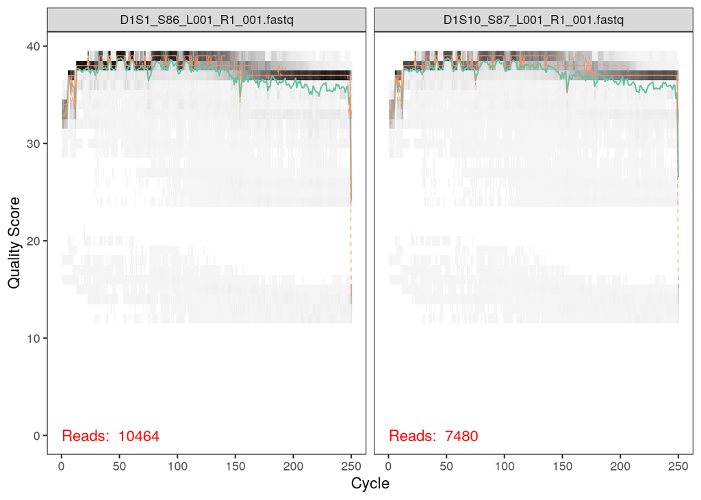

```r
R1_fnFs <- sort(list.files(dataPath, pattern="_R1_001.fastq", full.names = TRUE))
R2_fnRs <- sort(list.files(dataPath, pattern="_R2_001.fastq", full.names = TRUE))

sample.names <- sapply(strsplit(basename(R1_fnFs), "_"), `[`, 1)

plotQualityProfile(R1_fnFs[1:2])
```

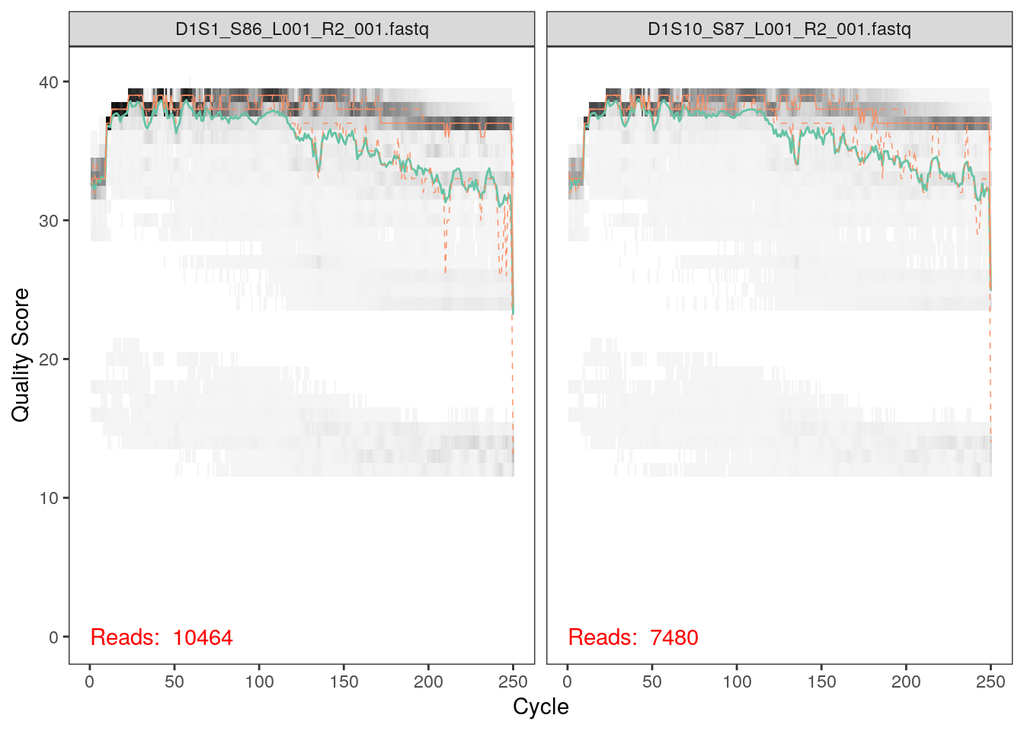

```r
plotQualityProfile(R2_fnRs[1:2])
```

### Quality Filtering

Here we filter the data to prepare it for the merge step.

```r
out <- filterAndTrim(R1_fnFs, R1_filtFs, R2_fnRs, R2_filtRs, truncLen=c(240,200),
                     maxN=0, maxEE=c(2,2), truncQ=2, rm.phix=TRUE,
                     compress=TRUE, multithread=TRUE) # On Windows set multithread=FALSE
```

In my very limited experience truncLen has been the most infuential parameter, some trimming is important to remove messy sequences but too much trimming can lead reduced overlap and lots of lost sequences in the merge step.

### Merging

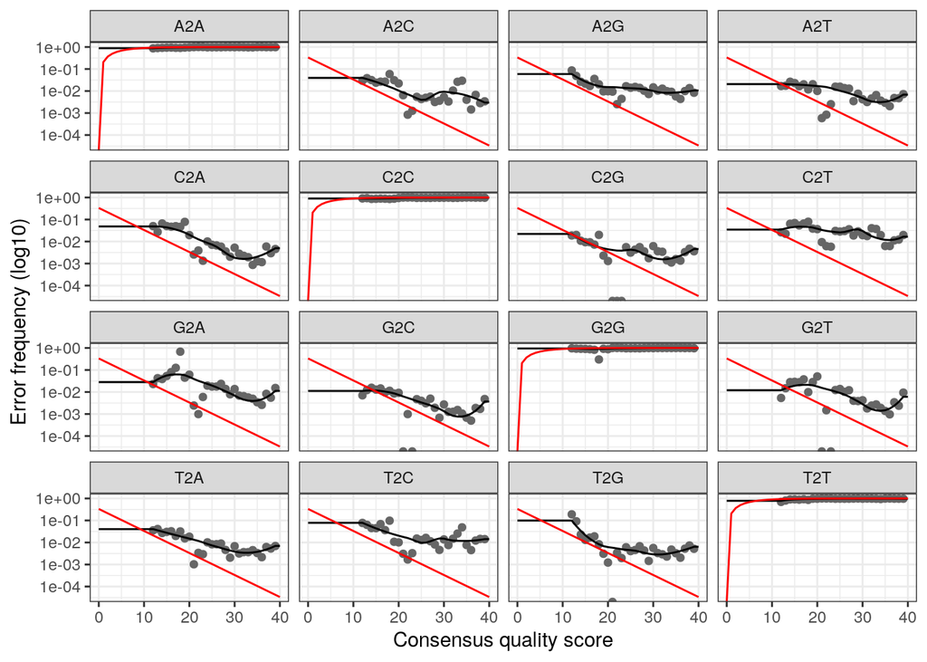

```r
errF <- learnErrors(R1_filtFs, multithread=TRUE)
errR <- learnErrors(R2_filtRs, multithread=TRUE)
plotErrors(errF, nominalQ=TRUE)
```

### Merge Results

The columns of the following table are the lengths, in nucleotides, of the merged sequences and the entries are the number of seqeunces of that length.  
**Sanity Check** - Compare the distribution of merge lengths to what you would expect based on the length of the sequence you amplified. Are they as expected? If not you may need to return to the filterAndTrim step and adjust the parameters.

```r
seqtab <- makeSequenceTable(mergers)
table(nchar(getSequences(seqtab)))
```

```
##
##  267  373  380  398  403  406  407  408  409  410  411  412  413  414  415  416
##    1    2    1    1   13    6   56   21   69   42  522  150 3563  883 1042   44
##  417  418  419  421  423  424  425  426  427  428
##   24   19    1   10   10    9   13   17    2    6
```

### Removing Chimeras

We remove Chimeras then check the ratio of non-chimera sequences to total merged sequences. The closer this ratio is to 1.0 the better.

```r
seqtab.nochim <- removeBimeraDenovo(seqtab, method="consensus", multithread=TRUE, verbose=TRUE)
```

```
## Identified 3890 bimeras out of 6527 input sequences.
```

```r
sum(seqtab.nochim)/sum(seqtab)
```

```
## [1] 0.7096494
```

### Check for loss:

Here we can get an idea of how many sequences we lost in each of the above steps. The last column is the percentage of reads that made is all the way through.

```r
getN <- function(x) sum(getUniques(x))
summary_tab <- data.frame(row.names=sample.names, dada2_input=out[,1],
                          filtered=out[,2], dada_f=sapply(dadaFs, getN),
                          dada_r=sapply(dadaRs, getN), merged=sapply(mergers, getN),
                          nonchim=rowSums(seqtab.nochim),
                          final_percent=round(rowSums(seqtab.nochim)/out[,1]*100, 1))

summary_tab
```

|  | dada2_input | filtered | dada_f | dada_r | merged | nonchim | final_percent |
| --- | --- | --- | --- | --- | --- | --- | --- |
| D1S1 | 10464 | 9934 | 8590 | 8979 | 6702 | 5064 | 48.4 |
| D1S10 | 7480 | 7160 | 5948 | 6320 | 4675 | 3704 | 49.5 |
| D1S2 | 17559 | 16722 | 14559 | 15511 | 12041 | 9094 | 51.8 |
| D1S3 | 7088 | 6806 | 5673 | 6045 | 4490 | 3447 | 48.6 |
| D1S4 | 10180 | 9622 | 8560 | 8924 | 7404 | 5457 | 53.6 |
| D1S5 | 14936 | 14063 | 12270 | 12812 | 9851 | 7412 | 49.6 |
| D1S6 | 7269 | 6870 | 5803 | 6156 | 4597 | 3436 | 47.3 |
| D1S7 | 10415 | 9821 | 8368 | 8860 | 6632 | 5400 | 51.8 |
| D1S8 | 10089 | 9529 | 8142 | 8735 | 6511 | 4834 | 47.9 |
| D1S9 | 7967 | 7555 | 6209 | 6631 | 4856 | 3823 | 48.0 |

[output cut: 26 more lines]

### Assigning Taxa

We assign taxonomic labels to our data by cross referencing it with labelled data. You can find multiple datasets to reference against here:https://benjjneb.github.io/dada2/training.html

We need to download into our working directory:

```r
taxa <- assignTaxonomy(seqtab.nochim, paste0(dataPath,"/IDTaxa/silva_nr_v132_train_set.fa.gz"), multithread=TRUE)
summary(taxa)
```

```
##       Kingdom                Phylum                     Class
##  Archaea  :   5   Proteobacteria:1473   Alphaproteobacteria:856
##  Bacteria :2623   Bacteroidetes : 605   Bacteroidia        :583
##  Eukaryota:   5   Cyanobacteria : 208   Gammaproteobacteria:506
##  NA's     :   4   Planctomycetes: 187   Oxyphotobacteria   :207
##                   Lentisphaerae :  32   Deltaproteobacteria:102
##                   (Other)       : 109   (Other)            :333
##                   NA's          :  23   NA's               : 50
##               Order                    Family               Genus
##  Rhodobacterales : 497   Rhodobacteraceae : 497   Erythrobacter:  50
##  Flavobacteriales: 309   Flavobacteriaceae: 248   Alteromonas  :  44
##  Chloroplast     : 172   Saprospiraceae   : 131   Aquibacter   :  37
##  Alteromonadales : 148   Alteromonadaceae : 105   Robiginitalea:  33
##  Chitinophagales : 139   Mitochondria     :  89   SM1A02       :  31
##  (Other)         :1145   (Other)          :1029   (Other)      :1112
##  NA's            : 227   NA's             : 538   NA's         :1330
```

From the summary output we can see that some of the sequences are not ones we’re interested in: Eukaryotes, Mitochondria and Chloroplasts. We’ll remove them.  
**We need to remove from the Taxa Table and the Sequence Tabel**.

```r
is.mito <- taxa[,"Family"] %in% "Mitochondria"
is.chloro <- taxa[,"Order"] %in% "Chloroplast"
is.euk <- taxa[,"Kingdom"] %in% "Eukaryota"

to.remove <- Reduce("|", list(is.mito,is.chloro, is.euk))
taxa.trimmed <- taxa[!to.remove,]
seqtab.trimmed <- seqtab.nochim[,!to.remove]
summary(taxa.trimmed)
```

```
##      Kingdom                Phylum                     Class
##  Archaea :   5   Proteobacteria:1384   Alphaproteobacteria:767
##  Bacteria:2362   Bacteroidetes : 605   Bacteroidia        :583
##  NA's    :   4   Planctomycetes: 187   Gammaproteobacteria:506
##                  Cyanobacteria :  36   Deltaproteobacteria:102
##                  Lentisphaerae :  32   Planctomycetacia   : 61
##                  (Other)       : 109   (Other)            :307
##                  NA's          :  18   NA's               : 45
##               Order                   Family              Genus
##  Rhodobacterales :497   Rhodobacteraceae :497   Erythrobacter:  50
##  Flavobacteriales:309   Flavobacteriaceae:248   Alteromonas  :  44
##  Alteromonadales :148   Saprospiraceae   :131   Aquibacter   :  37
##  Chitinophagales :139   Alteromonadaceae :105   Robiginitalea:  33
##  Cytophagales    :110   Cyclobacteriaceae: 88   SM1A02       :  31
##  (Other)         :946   (Other)          :941   (Other)      :1112
##  NA's            :222   NA's             :361   NA's         :1064
```

### Assign Species

Next we expand classification to the species level. We only match a handful of species. Oh well.

```r
taxa.final <- addSpecies(taxa.trimmed, paste0(dataPath,"/IDTaxa/silva_species_assignment_v132.fa.gz"))
taxa.print <- taxa.final # Removing sequence rownames for display only
temp <- taxa.final
rownames(temp)  <- NULL
species<- na.omit(temp[,"Species"])
head(species, length(species))
```

```
##  [1] "italica"       "ishigakiensis" "mesophilus"    "geojense"
##  [5] "spongiae"      "caesariensis"  "litorea"       "lutimaris"
##  [9] "aggregatus"    "marinus"       "conchae"       "antarcticus"
## [13] "xishaensis"    "litoralis"     "insulae"       "vulgaris"
```

### Exporting the Data

This is a good point to save our results before getting into data analysis. Comma Seperated Values (csv) or Tab Seperated Values (tsv) are a portable format for large tables. I prefer TSVs. If you prefer CSVs change the following:

1. “filename.tsv” -> “filname.csv”
2. sep - “\t” -> sep =“,”

```r
write.table(taxa.final, "Silva_Assigned.tsv", sep = "\t", quote=FALSE, col.names = NA)

asv_seqs <- colnames(seqtab.trimmed)
asv_headers <- vector(dim(seqtab.trimmed)[2], mode="character")

for (i in 1:dim(seqtab.trimmed)[2]) {
  asv_headers[i] <- paste(">ASV", i, sep="_")
}

# making and writing out a fasta of our final ASV seqs:
asv_fasta <- c(rbind(asv_headers, asv_seqs))
write(asv_fasta, "ASVs.fa")

# count table:
asv_tab <- t(seqtab.trimmed)
row.names(asv_tab) <- sub(">", "", asv_headers)
write.table(asv_tab, "ASVs_counts.tsv", sep="\t", quote=F, col.names=NA)

asv_tax <- taxa.final
row.names(asv_tax) <- sub(">", "", asv_headers)
write.table(asv_tax, "ASVs_taxonomy.tsv", sep="\t", quote=F, col.names=NA)
```

### Epilogue: Normalization Across Samples

(You may prefer to include this in a separate data analysis script)

For normalization we’re going to use the DESeq2 package

```r
if (!requireNamespace("BiocManager", quietly = TRUE))
    install.packages("BiocManager")

BiocManager::install("DESeq2")
```

```r
library("DESeq2")
```

We’re going to re-import our data and bring in a new file - “sample_treatment.tsv”. This file is a metadata file with samples and their experimental treatment.

```r
count_tab <- read.table("ASVs_counts.tsv", header=T, row.names=1,
                        check.names=F, sep="\t")

tax_tab <- as.matrix(read.table("ASVs_taxonomy.tsv", header=T,
                                row.names=1, check.names=F, sep="\t"))

sample_info_tab <- read.table("sample_treatment.tsv", header=T, row.names=1,
                              check.names=F, sep="\t")
sample_info_tab
```

|  | Time | Treatment | Choice | color |
| --- | --- | --- | --- | --- |
| D1W1 | 1 | W | 1 | black |
| D1W2 | 1 | W | 1 | black |
| D1W3 | 1 | W | 1 | black |
| D2W4 | 2 | W | 1 | black |
| D2W5 | 2 | W | 2 | black |
| D2W6 | 2 | W | 1 | black |
| D1S1 | 1 | S | 1 | red |
| D1S2 | 1 | S | 2 | red |
| D1S3 | 1 | S | 1 | red |
| D1S4 | 1 | S | 1 | red |

[output cut: 26 more lines]

## Important Data Preparation Checks

### First Important Check

We may want to remove ASVs which show up in insubstantial quantity. For example if there are only one or two instances of an ASV across all samples, we might toss it out. Below we remove all ASVs that only show up once.

```r
minimum_threshold = 1
count_tab = count_tab[rowSums(count_tab) > minimum_threshold, ]
```

### Second Important Check

We need to make sure the column names from “count_tab” are matched to row_names from “sample_treatment.tsv”. That means the sample names must be **exactly** the same (spelling, capitalization, order). Here we make sure the tables are sorted in the same order and check that the names match.

```r
sample_info_tab = sample_info_tab[order(row.names(sample_info_tab)), ]
count_tab = count_tab[ , order(names(count_tab))]

print(colnames(count_tab) == rownames(sample_info_tab)) # This has to return TRUE for all entries, if it doesnt make sure sample names are the same
```

```
##  [1] TRUE TRUE TRUE TRUE TRUE TRUE TRUE TRUE TRUE TRUE TRUE TRUE TRUE TRUE TRUE
## [16] TRUE TRUE TRUE TRUE TRUE TRUE TRUE TRUE TRUE TRUE TRUE TRUE TRUE TRUE TRUE
## [31] TRUE TRUE TRUE TRUE TRUE TRUE
```

### Third Imporant Check

For some statistical analyses (e.g. Bray-Curtis) we cannot have sample columns that consist entirely of zeroes - i.e. experimental samples which contain no merged sequences. Let’s remove those from count_tab and the corresponding entries from sample_info_tab

```r
nonZeroes = count_tab[, colSums(count_tab) != 0]
count_tab = count_tab[, colnames(nonZeroes)]
sample_info_tab = sample_info_tab[colnames(nonZeroes),  ]
```

### Normalize

Now we’re ready to normalize.  
In the DESeqDataSetFromMatrix, make sure that the “design” parameter is set against the variable of interest from the sample metadata file. In this project that information is stored in the “Treatment” variable. If there are multiple variables of interest you can use: design ~ var1 + var2 + var3 + …

```r
deseq_counts <- DESeqDataSetFromMatrix(countData = count_tab, colData = sample_info_tab, design = ~ Treatment)

deseq_counts <- estimateSizeFactors(deseq_counts, type = "poscount") #do this step when there are lots of "0" entries
deseq_counts_vst <- varianceStabilizingTransformation(deseq_counts)

# and here is pulling out our transformed table
vst_trans_count_tab <- assay(deseq_counts_vst)
```

### Negative Values

The normalization steps above will produce both positive and negative values. Some downstream analysis methods require positive values. We can shift our values so that they are all positive, while maintaining the distribution, by adding the absolute value of the most negative number to each entry:

```r
vst_trans_count_tab.2 <- ceiling(abs(min(vst_trans_count_tab))) + vst_trans_count_tab
```

.